# southernMaps package: mapping

Olivia Burge

2017-07-21

## Introduction

This package aims to provide Southern Hemisphere maps in easy forms for use. Therefore it provides functions, but also datasets. The datasets, for easy reference, are:

1. nzSml, nzMed, nzHigh - shapefiles of the NZ coastline in NZTM projection
2. nzSml84, nzMed84, nzHigh84 - shapefiles of the NZ coastline in WGS84 projection.

If your data is in lat/lon, you want WGS84. The data load automatically, so you don’t need to run anything. See below for examples

## NZ maps

The `map(nz)` command in base R returns different projection than expected (ie, not WGS84). If you want a map of NZ that’s not too detailed, you can use `nzSml`.

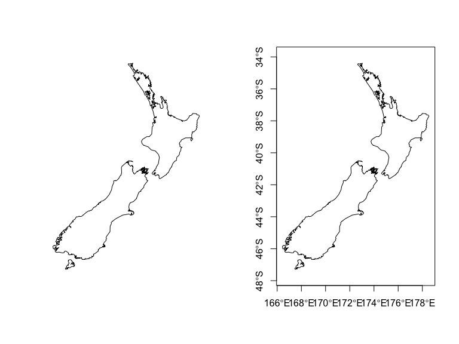

A low-res map of NZ in base map

```r
par(mfrow = c(1, 2))
plot(nzSml84)
plot(nzSml84, axes = TRUE) # with basic axes
```

```r
par(mfrow = c(1,1))
```

If you want to plot it in **ggplot2**, you need to convert to a dataframe. Use the `fortify_polygons()` function.

```r
nz_DF84 <- fortify_polygons(shape = nzSml84, proj = "wgs84")
```

Note that you specify the projection you want back. This can be useful if you have a shapefile in an old format (e.g. NZMG) and want to go to either WGS84 or NZTM.

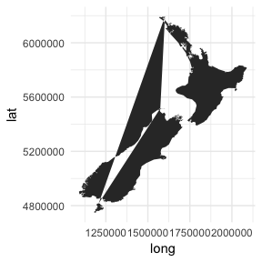

```r
nz_DF <- fortify_polygons(shape = nzSml84, proj = "nztm")

require(ggplot2)
ggplot(nz_DF, aes(x = long, y = lat)) +
  geom_polygon() +
  theme_minimal()
```

That doesn’t look very good. We need to specify which polygons should be drawn independently. For example, the North Island should be drawn as a stand-along polygon, not connected to Stewart Island. We use the `group` argument for this:

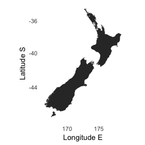

```r
ggplot(nz_DF84, aes(x = long, y = lat)) +
  geom_polygon(aes(group = group)) +
  theme_minimal() +
  coord_map() +
  labs(x = "Longitude E", y = "Latitude S") +
  theme(panel.grid = element_blank())
```

Note the `theme` and `coord_map` and `labs` arguments. If you aren’t already familiar with **ggplot2**, try commenting them out and see the difference.

All of the above also applies to `nzMed` and `nzHigh`.

## Plotting small islands in high resolution

This section also relates to plotting small areas of NZ in high detail. The key function is `find_my_island()`, which returns islands from the data object `detailed_nz_islands`. It returns the islands its found by searching across the various shapefile fields. Easiest to show by example:

```r
isle <- find_my_island("codfish", proj = "nztm")
```

```
##                        name grp_name
## 1 Codfish Island/Whenua Hou     <NA>
## [1] "1 match(es) found. Site(s) found listed above"
```

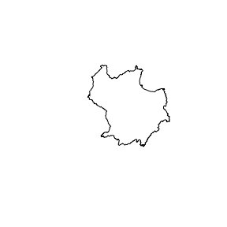

```r
plot(isle)
```

And to plot in **ggplot2**:

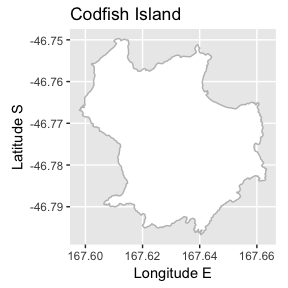

```r
isle_df <- fortify_polygons(isle, "wgs84")

idf <- ggplot(isle_df, aes(x = long, y = lat)) +
  geom_polygon(colour = "grey", fill = "white")+
  coord_map() +
  labs(x = "Longitude E", y = "Latitude S",
       title = "Codfish Island")

idf
```

You can also do multiple islands at once:

```r
# multiple islands
many <- find_my_island(c("auckland", "campbell")) %>%
  fortify_polygons("nztm")
```

```
##                            name         grp_name
## 1                  Adams Island Auckland Islands
## 2                   Adams Rocks Auckland Islands
## 3                  Amherst Rock Auckland Islands
## 4                   Archer Rock Auckland Islands
## 5               Auckland Island Auckland Islands
## 6                   Beacon Rock Auckland Islands
## 7                  Beehive Rock Auckland Islands
## 8                  Blanche Rock Auckland Islands
## 9  Campbell Island/Motu Ihupuku             <NA>
## 10                 Column Rocks Auckland Islands
## 11                Compadre Rock Auckland Islands
## 12                Detached Rock Auckland Islands
## 13        Disappointment Island Auckland Islands
## 14                Dundas Island Auckland Islands
```

[output cut: 19 more lines]

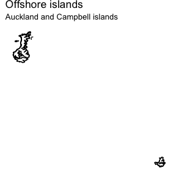

```r
# the chain command %>% is from dplyr
# just skips the intermediate assignment

ggplot(many, aes(x = long,y  = lat)) +
  geom_path(aes(group = group)) +
  coord_equal() +
  labs(title = "Offshore islands", subtitle = "Auckland and Campbell islands") +
  theme_void() # no axes, nothing
```

## Adding points

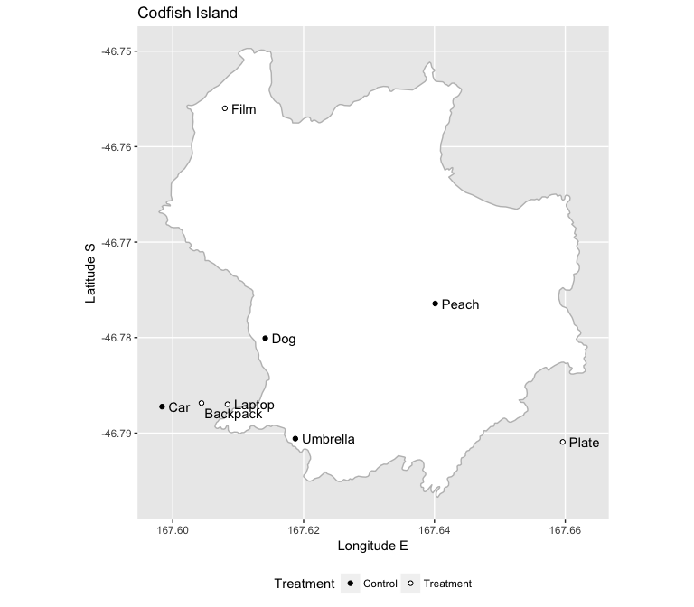

```r
some_points <- data.frame(longitude = runif(8, min = min(isle_df$long) + 0.0001, max = max(isle_df$long) - 0.0001),
                          latitude = runif(8, min = min(isle_df$lat) + 0.0001, max = max(isle_df$lat) - 0.0001),
                          type = c(rep("Control", 4), rep("Treatment", 4)),
                          siteName = c("Umbrella", "Peach", "Car", "Dog", "Film", "Laptop", "Backpack", "Plate"))

idf +
  geom_point(data = some_points, aes(x = longitude, y = latitude, fill = type),
             shape = 21, colour = "black") +
  scale_fill_manual(values = c("black", "white")) +
  theme(legend.position = "bottom") +
  labs(fill = "Treatment") +
  geom_text(data = some_points %>% filter(siteName != "Backpack"), aes(x = longitude, y = latitude, label = siteName),
            nudge_x = 0.001,
            hjust = 0) +
    geom_text(data = some_points %>% filter(siteName == "Backpack"), aes(x = longitude, y = latitude, label = siteName),
            nudge_x = 0.0005,
            nudge_y = -0.001,
            hjust = 0)
```